# Required Packages:

- NumPy: For arrays, and various linear algebra operations.
- Matplotlib: For visualizing and viewing images.
- Scikit Learn: For Olivetti faces dataset, PCA, LDA models and metrics.
- Jupyter Lab: For running Jupyter Notebooks.

All these packages are mentioned in `requirements.txt`

```python
import numpy as np
from sklearn.datasets import fetch_olivetti_faces, make_blobs
from sklearn.decomposition import PCA
from sklearn.discriminant_analysis import LinearDiscriminantAnalysis
from sklearn.pipeline import Pipeline
from sklearn.metrics import accuracy_score, confusion_matrix, ConfusionMatrixDisplay
import matplotlib.pyplot as plt
from IPython.display import display, Math
```

# Linear Discriminant Analysis (LDA):

LDA is a supervised machine learning and statistical technique used for classification and dimensionality reduction. It projects data from high dimensions to lower dimensions, while maximising between class separation and minimising within-class scatter.

PCA projects onto lower dimensions while preserving maximum variance, however maximum variance does not guarantee maximum class separation. Also face recognition is a supervised learning problems because we have to deal with labeled dataset. However this does not leave behind PCA, instead PCA plays a key role in creating an effective LDA based model.

PCA-based face representation are commonly referred as Eigenfaces, while PCA followed by LDA produces Fisherfaces.

# The mathematics:

Suppose a dataset has $n$ features, $N$ samples and $C$ classes.

For LDA, we have to maximize the distance between the means of classes, i.e. $S_{b}=\sum_{c=1}^{C}{N_{c}(\mu_c-\mu)(\mu_c-\mu)^{T}}$ and minimize the within class scatter, i.e. $S_w=\sum_{c=1}^{C}{\sum_{x\in c}{(x-\mu_c)(x-\mu_c)^{T}}}$

The objective function for LDA becomes: $$\begin{align} & J = \frac{w^{T}S_bw}{w^{T}S_ww} \implies S_{b}w=\lambda S_{w}w \end{align}$$ The vector $w$ gives the direction of maximum separability, and the $S_bw=\lambda S_ww$ is the generalized eigenvalue problem which can be solved computationally using `scipy.linalg.eigh(S_b, S_w)`

There are some additional constraints that we need to take care of:

1. $S_b$ can only have atmost rank of $C-1$, which leads to atmost $C-1$ non-zero eigenvalues. Hence we can only reduce dimensions $\leq C-1$
2. If $rank(S_w)\leq N-C$, till this condition it is non-singular. For $n>N-C$, $S_w$ becomes singular.

Solution for this:

To force invertability on $S_w$ we add a factor of $\gamma I$. Also we reduce the features i.e. the dimensions of the original dataset using PCA to solve the second constraint.

After finding the directions in which the conditions are met, we have to project our higher dimension points onto the lower dimension.

Every new point is again projected on this lower dimensional subspace and the distance from class is measured. Whichever class is near is the predicted class!

A from scratch implementation exists in this project. It can found at `LDA/linear_discriminant_analysis.py`

# Visualizing LDA:

First we'll need to make a synthetic dataset and plot it.

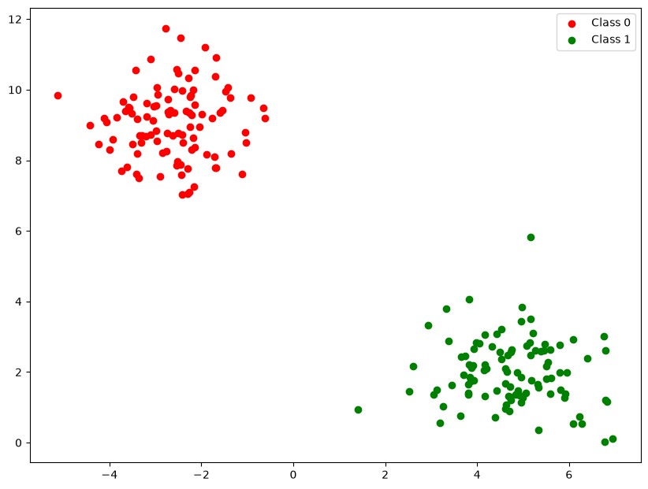

```python
X, y = make_blobs(
    n_samples=200,
    n_features=2,
    centers=2,
    random_state=42
)

X0, X1 = X[y == 0], X[y == 1]
plt.figure(figsize=(10, 7.5))
plt.scatter(X0[:, 0], X0[:, 1], color="red", label="Class 0")
plt.scatter(X1[:, 0], X1[:, 1], color="green", label="Class 1")
plt.legend(loc="upper right")
plt.show()
```

# Projecting data from higher dimensional space to lower dimensional sub-space:

We will use the from-scratch implementation here.

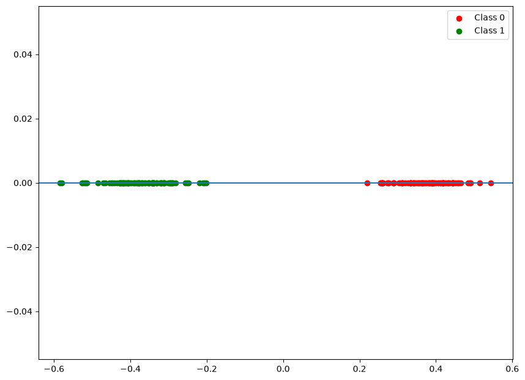

```python
from LDA.linear_discriminant_analysis import LDA

lda = LDA(n_components=1)
projection = lda.fit_transform(X, y)
projection0, projection1 = projection[y == 0], projection[y == 1]

plt.figure(figsize=(10, 7.5))
plt.scatter(projection0.flatten(), [0]*len(projection0), color="red", label="Class 0")
plt.scatter(projection1.flatten(), [0]*len(projection1), color="green", label="Class 1")
plt.legend(loc="upper right")
plt.axhline(y=0)
plt.show()
```

# Application to Face Recognition:

Here we will use the implementation from Scikit Learn. The logic is same, maximize the between class separability and minimize within class separability.

Perform PCA if needed.

Since, we are using Olivetti faces dataset, the dataset has 40 subjects with 10 images each and size 4096. The size becomes the features for the dataset.

For train-test split we will keep 8 images for each subject in the training dataset and remaining in the test dataset.

So there would be $8\times 40=320$ samples and $40$ classes and features must be $\leq 320-40\implies\leq280$

We will reduce this to our $4096$ features dataset to $80$ features and use $30$ components for LDA.

## Dataset preparation:

First we will prepare our dataset. For that we need to setup some constants.

```python
N_SUBJECTS = 40
TRAIN_PER_SUBJECT = 8
TEST_PER_SUBJECT = 2
IMG_SIZE = 4096
IMG_SHAPE = (64, 64)
TOTAL_IMAGES = 400
IMAGES_PER_SUBJECT = 10
PCA__N_COMPONENTS = 80
LDA__N_COMPONENTS = 30
```

### Creating train test datasets:

As mentioned, train dataset will have 8 images of 40 subjects and test dataset will have 2 images of 40 subjects.

```python
dataset = fetch_olivetti_faces()
images = dataset.data

train_dataset = np.empty((N_SUBJECTS, TRAIN_PER_SUBJECT, IMG_SIZE))
test_dataset = np.empty((N_SUBJECTS, TEST_PER_SUBJECT, IMG_SIZE))

for i in range(0, TOTAL_IMAGES, IMAGES_PER_SUBJECT):
    train_dataset[i//IMAGES_PER_SUBJECT, :, :] = images[i:i+TRAIN_PER_SUBJECT]
    test_dataset[i//IMAGES_PER_SUBJECT, :, :] = images[i+TRAIN_PER_SUBJECT:i+IMAGES_PER_SUBJECT]

train_dataset = train_dataset.reshape(-1, IMG_SIZE)
y_train = np.repeat(np.arange(N_SUBJECTS), TRAIN_PER_SUBJECT)
test_dataset = test_dataset.reshape(-1, IMG_SIZE)
y_test = np.repeat(np.arange(N_SUBJECTS), TEST_PER_SUBJECT)
```

## Creating pipeline:

```python
pca = PCA(n_components=PCA__N_COMPONENTS, random_state=42)
lda = LinearDiscriminantAnalysis(n_components=LDA__N_COMPONENTS)

model = Pipeline([("pca", pca), ("lda", lda)])
model.fit(train_dataset, y_train)
```

```
Pipeline(steps=[('pca', PCA(n_components=80, random_state=42)),
                ('lda', LinearDiscriminantAnalysis(n_components=30))])
```

# Fisherfaces:

Now we will take a look at first few fisherfaces.

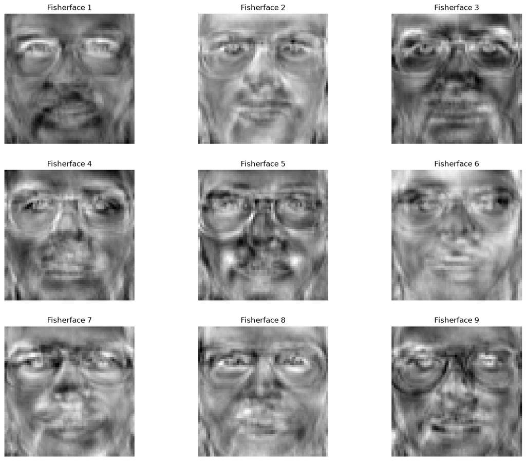

```python
fisherfaces = pca.components_.T @ lda.scalings_[:, :LDA__N_COMPONENTS]

fig, axes = plt.subplots(3, 3, figsize=(16, 13))

for i, ax in enumerate(axes.flatten()):
    ax.imshow(fisherfaces[:, i].reshape(IMG_SHAPE), cmap="gray")
    ax.set_title(f"Fisherface {i+1}")
    ax.axis("off")

plt.show()
```

These fisherfaces jointly capture discriminating facial regions; such as jaw edges and eye spacing, that reliably differ between individuals while staying stable within each person's own variations.

# Testing the model:

We will now use the `test_dataset` to evaluate out model.

## Picking a test image:

We will randomly select a test image.

```python
rng = np.random.default_rng(seed=144)
test_image_idx = rng.integers(0, TEST_PER_SUBJECT*N_SUBJECTS, size=1)
test_image_vector = test_dataset[test_image_idx]
```

## Finding class of test face:

Now we will predict the class of the test face. This will only tell us the predicted class, but we will pick a random face from predicted class and compare them.

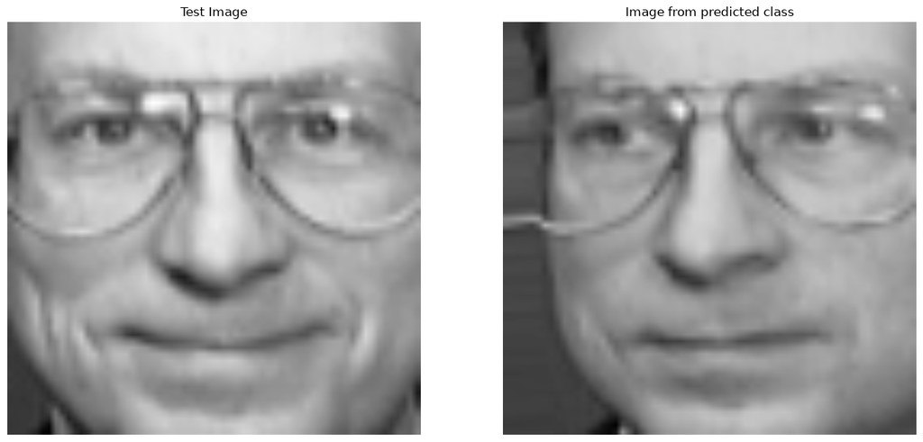

```python
predicted_class = model.predict(test_image_vector)

random_img_idx = rng.integers(0, TRAIN_PER_SUBJECT, size=1)
predicted_class_subject = train_dataset[predicted_class*TRAIN_PER_SUBJECT+random_img_idx, :].reshape(IMG_SHAPE)

fig, axes = plt.subplots(1, 2, figsize=(16, 10))

axes[0].imshow(test_image_vector.reshape(IMG_SHAPE), cmap="gray", interpolation="bilinear")
axes[0].set_title("Test Image")

axes[1].imshow(predicted_class_subject, cmap="gray", interpolation="bilinear")
axes[1].set_title("Image from predicted class")

for ax in axes:
    ax.axis("off")

plt.show()
```

# Some important metrics:

Since the test image is selected at random, there is a chance that the model did not show the failed case. Here we will take a look at Accuracy Score and Confusion Matrix.

## Accuracy Score:

```python
y_predicted = model.predict(test_dataset)

accuracy = accuracy_score(y_test, y_predicted)*100
display(Math(r"\text{Accuracy Score}="+f"{accuracy}"+r"\%"))
```

$\displaystyle \text{Accuracy Score}=97.5\%$

The eigenfaces approach got us $88.8\%$ accuracy but our fisherfaces approach got us a $97.5\%$ accuracy! The dataset here used is small, so each misclassified image costs $1.25\%$ accuracy.

## Confusion Matrix:

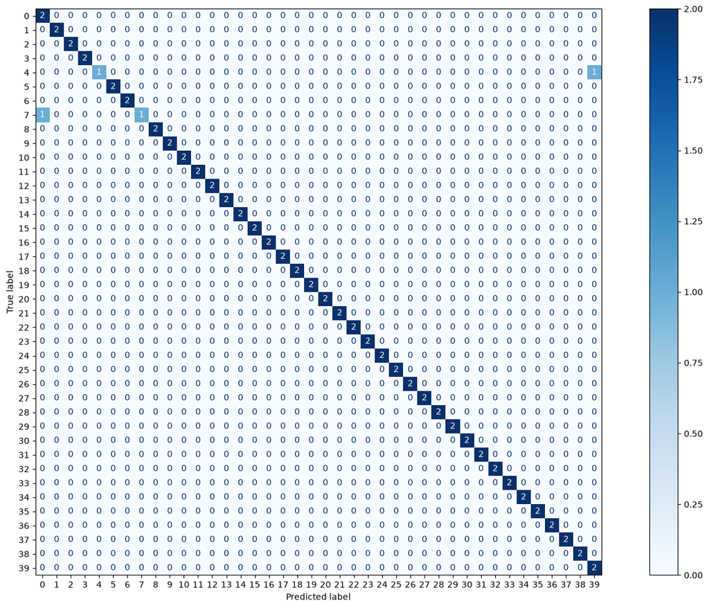

```python
cm = confusion_matrix(y_test, y_predicted)
figure, ax = plt.subplots(figsize=(16, 10))
disp = ConfusionMatrixDisplay(confusion_matrix=cm)

disp.plot(ax=ax, cmap=plt.cm.Blues)
plt.tight_layout()
plt.show()
```

This matrix tells us that for Subject 4 and 7, one image is classified correctly and other image is incorrectly classified.